# 4. GNU/Linux - Filesystem - File Tree

```bash
cat /etc/os-release | grep 'PRETTY*'
```

```
PRETTY_NAME="Debian GNU/Linux 12 (bookworm)"
```

# 4.0 Commands Handout

[output not shown]

File-type encoding used by `ls`

| File type | Symbol | Created by | Removed by |
| --- | --- | --- | --- |
| Regular file | `-` | `editors`, `cp`, etc. | `rm` |
| Directory | `d` | `mkdir` | `rmdir`, `rm -r` |
| Character device file | `c` | `mknod` | `rm` |
| Block device file | `b` | `mknod` | `rm` |
| Local domain socket | `s` | `socket` system call | `rm` |
| Named pipe | `p` | `mknod` | `rm` |
| Symbolic link | `l` | `ln -s` | `rm` |

Standard directories and and their contents

[output not shown]

The distinguishing characteristic of `/sbin` was originally that its contents were *statically linked* and so had fewer dependencies on other parts of the system. These days, all binaries are dynamically linked and there is no real difference between `/bin` and `/sbin`.

# 4.1 Introduction

The basic purpose of a filesystem is to represent and organize the system’s storage resources.

The filesystem can be thought of as comprising four main components:

- A namespace – a way to name things and organize them in a hierarchy,
- An API – a set of system calls for navigating and manipulating objects,
- Security models – schemes for protecting, hiding, and sharing things,
- An implementation – software to tie the logical model to the hardware.

An **API**, or application programming interface, is the generic term for the set of routines that a library, operating system, or software package permits programmers to call.

# 4.2 Filesystem structure

In Linux, files are organized within a hierarchy of directories. Each directory can contain files as well as other directories. You can refer to any file or directory using either

- a full path (for example, `/ home/joe/myfile.txt`) or
- a relative path (for example, if `/home/joe` were your current directory, you could simply refer to the file as `myfile.txt`).

If you were to map out the files and directories in Linux, it would look like an upside-down tree. At the top is the root directory (not to be confused with the root user), which is represented by a single slash (`/`). Below that is a set of common directories in the Linux system, such as `bin`, `dev`, `home`, `lib`, and `tmp`, to name a few. Each of those directories, as well as directories added to the root directory, can contain subdirectories.

```bash
tree / -dL 1
```

```
/
├── bin -> usr/bin
├── boot
├── dev
├── etc
├── home
├── lib -> usr/lib
├── lib32 -> usr/lib32
├── lib64 -> usr/lib64
├── lost+found
├── media
├── mnt
├── opt
├── proc
├── root
├── run
├── sbin -> usr/sbin
├── snap
├── srv
├── sys
├── tmp
├── usr
└── var

23 directories
```

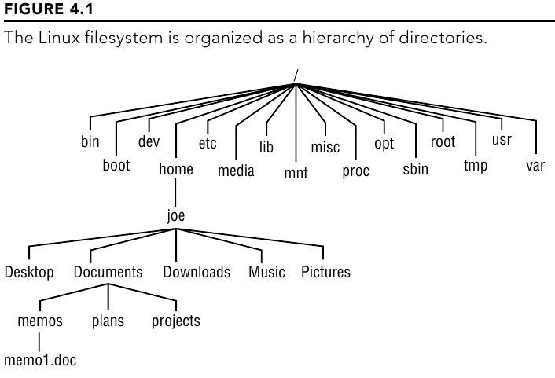

*"Unix and Linux System Administration Handbook" by Evi Nemeth, Garth Snyder, Trent R. Hein, Ben Whaley, and Dan Mackin, p.94*

The filesystem can be arbitrarily deep. However, each component of a **pathname** (that is, each directory) must have a name no more than `255` characters long. There’s also a limit on the total path length you can pass into the kernel as a system call argument:

- `4,095` bytes on Linux,
- `1,024` bytes on BSD.

To access a file with a pathname longer than this, you must `cd` to an intermediate directory and use a relative pathname.

See [FHS](https://wiki.linuxfoundation.org/lsb/fhs)

# 4.3 Filesystem mounting and unmounting

Most kernels have a nifty “loop” filesystem that lets you mount individual files as if they were distinct devices. It’s useful for mounting DVD-ROM images stored on disk or for developing filesystem images without having to worry about repartitioning. Linux systems can even treat existing portions of the file tree as filesystems. This trick lets you duplicate, move, or hide portions of the file tree.

## `mount`

`mount` maps a directory within the existing file tree, called the **mount point**, to the root of the newly attached filesystem. The previous contents of the mount point become temporarily inaccessible as long as another filesystem is mounted there. Mount points are usually empty directories, however.

```
$ sudo mount /dev/sda4 /users
```

installs the filesystem stored on the disk partition represented by `/dev/sda4` under the path `/users`. You could then use `ls /users` to see that filesystem’s contents.

*ChatGPT:*

1. **Mapping a Directory**:

   When you mount a filesystem using the `mount` command, you are essentially attaching that filesystem to a directory (or path) in your existing file tree. This directory is referred to as the **mount point**.

   For example, let's say you have a USB flash drive with a filesystem on it (e.g., FAT32, NTFS, ext4). When you plug in the USB drive and mount it, you choose a directory on your system to serve as the mount point. This directory will then act as the entry point for accessing the contents of the USB drive from your system.
2. **Temporary Inaccessibility of Previous Contents**:

   Before you mount a filesystem on a directory, that directory may contain files and directories of its own. However, once you mount a filesystem on it, the previous contents of the mount point become temporarily inaccessible. This is because the mount operation effectively overlays the existing directory structure with the contents of the newly attached filesystem.

   For example, if you have a directory named `/mnt/usb_drive` on your system and you mount a USB drive on it, any files or directories that were previously in `/mnt/usb_drive` will be hidden and inaccessible until you unmount the USB drive.
3. **Mount Points are Usually Empty Directories**:

   Mount points are typically empty directories created specifically for the purpose of mounting filesystems. This is because mounting a filesystem on an existing directory will hide its previous contents, as mentioned earlier.

   For example, before you mount a USB drive on `/mnt/usb_drive`, it's a good practice to ensure that `/mnt/usb_drive` is an empty directory. If it contains files or directories, they will be hidden and inaccessible once the USB drive is mounted.

## `/etc/fstab`

The `/etc/fstab` file lists filesystems that are normally mounted on the system. The information in this file allows filesystems to be automatically checked (with `fsck`) and mounted (with `mount`) at boot time, with options you specify. The `fstab` file also serves as documentation for the layout of the filesystems on disk and enables short commands such as `mount /usr`.

```bash
bat /etc/fstab
```

```
───────┬────────────────────────────────────────────────────────────────────────
       │ File: /etc/fstab
───────┼────────────────────────────────────────────────────────────────────────
   1   │ # /etc/fstab: static file system information.
   2   │ #
   3   │ # Use 'blkid' to print the universally unique identifier for a
   4   │ # device; this may be used with UUID= as a more robust way to name devi
       │ ces
   5   │ # that works even if disks are added and removed. See fstab(5).
   6   │ #
   7   │ # systemd generates mount units based on this file, see systemd.mount(5
       │ ).
   8   │ # Please run 'systemctl daemon-reload' after making changes here.
   9   │ #
  10   │ # <file system> <mount point>   <type>  <options>       <dump>  <pass>
  11   │ # / was on /dev/sda2 during installation
  12   │ UUID=a9f11a7b-eaae-4827-b59e-08b56b3cfb8a /               ext4    error
       │ s=remount-ro 0       1
  13   │ # /boot/efi was on /dev/sda1 during installation
  14   │ UUID=303A-3446  /boot/efi       vfat    umask=0077      0       1
  15   │ # /home was on /dev/sda4 during installation
  16   │ UUID=ef649054-312b-4057-8dbb-620a94c6946e /home           ext4    defau
       │ lts        0       2
  17   │ # swap was on /dev/sda3 during installation
  18   │ UUID=e84bc6e7-4bcd-488e-aa89-9a5ad52c70c4 none            swap    sw
       │            0       0
───────┴────────────────────────────────────────────────────────────────────────
```

## `umount`

You detach filesystems with the `umount` command. `umount` complains if you try to unmount a filesystem that’s in use. The filesystem to be detached must not have open files or processes whose current directories are located there, and if the filesystem contains executable programs, none of them can be running.

- Linux has a “lazy” unmount option (`umount -l`) that removes a filesystem from the naming hierarchy but does not truly unmount it until all existing file references have been closed. It’s debatable whether this is a useful option. To begin with, there’s no guarantee that existing references will ever close on their own. In addition, the “semi-unmounted” state can present inconsistent filesystem semantics to the programs that are using it; they can read and write through existing file handles but cannot open new files or perform other filesystem operations.
- `umount -f` force-unmounts a busy filesystem and is supported on all our example systems. However, it’s almost always a bad idea to use it on non-NFS mounts, and it may not work on certain types of filesystems (e.g., those that keep journals, such as XFS or ext4).

*ChatGPT*:  
Non-NFS mounts refer to file system mounts that are not utilizing the Network File System (NFS) protocol. NFS is a distributed file system protocol that allows remote systems to access files over a network as if they were local.

Non-NFS mounts, on the other hand, encompass a wide range of file system types and mechanisms that are used to mount storage devices or file systems locally on a system. These can include:

1. **Local Disk Mounts**: Mounting partitions or disk volumes directly attached to the local system, such as hard drives (HDDs), solid-state drives (SSDs), or external storage devices.
2. **File System Types**: Mounting various file system types supported by the operating system, such as ext4, NTFS, FAT32, and others.
3. **Virtual File Systems**: Mounting special-purpose file systems that provide access to kernel data structures or system information, such as `/proc`, `/sys`, and `/dev`.
4. **Loopback Devices**: Mounting disk images or files as if they were physical disks, using loopback devices. This allows treating a file containing a file system as a block device.
5. **Special Purpose Mounts**: Mounting other types of storage or resources, such as network block devices (NBD), RAM disks (tmpfs), or special-purpose file systems like FUSE (Filesystem in Userspace) mounts.

In summary, non-NFS mounts encompass any file system mounts that are not based on the NFS protocol for remote file access. They include a variety of local and special-purpose file system mounts used to access storage and resources on a system.

### Inspect processes of busy fs

```
$ lsof <mountpoint>
$ ps up "<list of PIDs>"  # if you need more info

# or in automatic mode
pids=($(lsof ~ | awk '{print $2}')) ; echo "${pids[@]:1}" | xargs ps up
```

- find out which processes hold references to that filesystem
- get the PID of every process that’s using a file or directory on that filesystem, plus a series of letter codes that show the nature of the activity
- investigate the offending processes

```bash
lsof ~/bin
```

```
COMMAND  PID  USER   FD   TYPE DEVICE SIZE/OFF    NODE NAME
bash    2650 commi  cwd    DIR    8,4     4096 7604608 /home/commi/bin
```

```bash
pids=($(lsof ~/bin | awk '{print $2}')) ; echo "${pids[@]:1}" | xargs ps up
```

```
USER         PID %CPU %MEM    VSZ   RSS TTY      STAT START   TIME COMMAND
commi       2650  0.0  0.0  10908  1856 pts/2    Ss   May05   0:00 /bin/bash
```

# 4.4 File Types

Most filesystem implementations define seven types of files:

- Regular files
- Directories
- Character device files
- Block device files
- Local domain sockets
- Named pipes (FIFOs)
- Symbolic links

## Regular files

- Regular files consist of a series of bytes; filesystems impose no structure on their contents.
  - Text files, data files, executable programs, and shared libraries are all stored as regular files.
- Both sequential access and random access are allowed.

## Directories

A directory contains named *references* to other files. You can create directories with `mkdir` and delete them with `rmdir` if they are empty. You can recursively delete nonempty directories — including all their contents — with `rm -r`.

The special entries `.` and `..` refer to the directory itself and to its parent directory; they cannot be removed. Since the root directory has no real parent directory, the path `/..` is equivalent to the path `/.` (and both are equivalent to `/`).

```bash
cd /tmp
mkdir test_dir
ls -ld test_dir

mkdir test_dir/test_dir
ls -ld test_dir

rm -rf test_dir
```

```
drwxr-xr-x 2 commi commi 4096 May 19 01:57 test_dir/
drwxr-xr-x 3 commi commi 4096 May 19 01:57 test_dir/
```

*ChatGPT*:

- **Initial Count**: When you create a directory, it starts with a link count of `2`. This count includes:
  - The directory itself (`test_dir` in your example).
  - The special entry `.` which is a link to the directory itself.
- **Parent Directory**: Each time a new subdirectory is created within a directory, the parent directory's link count is incremented by `1` because the parent directory now has a new link to the subdirectory via the `..` entry.

## Hard links

A file’s name is stored within its parent directory, not with the file itself. In fact, more than one directory (or more than one entry in a single directory) can refer to a file at one time, and the references can have different names. Such an arrangement creates the illusion that a file exists in more than one place at the same time.

These additional references (“links,” or “**hard links**” to distinguish them from **symbolic links**, discussed below) are synonymous with the original file; as far as the filesystem is concerned, all links to the file are equivalent. The filesystem maintains a count of the number of links that point to each file and does not release the file’s data blocks until its last link has been deleted.

> Hard links cannot cross filesystem boundaries.

### `ln`

You create hard links with `ln` and remove them with `rm`. It’s easy to remember the syntax of `ln` if you keep in mind that it mirrors the syntax of `cp`. The command `cp oldfile newfile` creates a copy of `oldfile` called `newfile`, and `ln oldfile newfile` makes the name `newfile` an additional reference to `oldfile`.

In most filesystem implementations, it is technically possible to make hard links to directories as well as to flat files. However, directory links often lead to degenerate conditions such as filesystem loops and directories that don’t have a single, unambiguous parent. In most cases, a symbolic link is a better option.

*ChatGPT:*  
While it is true that users cannot create additional hard links to directories (beyond the initial ones) due to the restrictions to prevent filesystem corruption, directories inherently have hard links created by the filesystem itself. See Directories

### More on links - *ChatGPT*

*ChatGPT*:  
In Unix-like operating systems such as GNU/Linux, files are indeed represented as **inodes**, which are data structures that contain information about

- the file and
- pointers to the actual data blocks on the storage device.

When a file is created, it's essentially creating an inode that points to the location of the file's data on the **storage device**. This inode could be considered a type of "hard link" in the sense that it's a pointer to the actual data.

However, in Unix-like systems, when we refer to "hard links" and "soft links" (symbolic links), we are typically talking about different ways of linking to the inodes rather than to the actual file data blocks on the storage device. A **hard link** is a direct *reference* to the inode of a file, while a **symbolic link** is a separate *file* that contains the path to the target file's inode.

#### Inodes - Index nodes

In GNU/Linux systems, files and directories are represented and managed by inodes.

An **inode** is a data structure that stores **metadata** about a file or directory, such as its

- location on the disk,
- size,
- ownership,
- permissions, and
- timestamps.

The actual data of the file is stored in the **data blocks** the inode points to.

Every file and directory is associated with an inode. Directories are essentially a file that contain the information about the inodes of their files and subdirectories.

Inodes are used by the file system to manage and access files and directories efficiently. Each inode has a unique identifier within the file system, allowing the operating system to track and manage files and directories.

Inodes are stored in a special area of the file system known as the **inode table** or **inode block**. This area is typically located at the beginning of the disk or within a designated section of the file system. The inode table contains a fixed number of entries, each of which represents a unique inode.

When a file or directory is created, the file system will allocate an available inode from the inode table and associate it with the newly created file or directory. The inode will then store all the necessary metadata and pointers to the actual data blocks on the disk.

When a file is created, modified, or accessed, the file system keeps track of the file using the inode number. This association allows the operating system to quickly locate, read, write, and manage files and directories by using their corresponding inodes.

In essence, the association between files and directories with their respective inodes is maintained by the file system, which uses the inode number to uniquely identify and manage each file or directory. This system ensures that all file-related information can be efficiently retrieved and stored by the operating system.

Inodes are an essential part of the file system structure, and their efficient management is crucial for the organization and retrieval of file-related information.

#### Hard and soft links

**Hard links** are the pointers to the inodes of the files (i.e. any file can be considered as a hard link). **Soft (symbolic) links** are files that contain the path to the file, so when you call the symlink you go to the path and call the hard link of the file in that path. This means, you can delete the file, thus the file path will lead to nowhere and the symlink will throw an error. On the contrary, when you delete a hard link you delete a pointer to the inode, this is where the "unlink" term comes from. - VR

When all hard links pointing to the same inode are deleted, the inode itself is not immediately removed. However, the data in the data blocks is no longer accessible through the file system. The inode and data blocks will only be released and marked as available for reuse by the file system once all hard links and open file descriptors pointing to the inode are removed, and the file is no longer in use by any process.

In Debian and other Linux distributions, hard and soft links are stored within the file system , i.e. in the directory they are created in. Both hard and soft links are created using the `ln` command.

Both hard and soft links are important features of the Linux file system and are managed at the operating system level.

**Hard link**

Hard links on GNU/Linux systems are useful for several reasons:

- **Reducing disk space usage:** Hard links allow multiple directory entries to refer to the same data blocks on disk. This means that you can have multiple users or processes accessing the same file without duplicating the actual data, which can save valuable disk space.
- **Maintaining consistency:** Hard links help maintain consistency across the file system by ensuring that there is only one physical copy of the data on disk, even if there are multiple directory entries pointing to it.
- **Improving performance:** Hard links can improve performance for certain operations, such as file system traversal and copying, by minimizing the amount of data that needs to be processed.

Overall, hard links are a powerful and efficient tool for managing file systems on GNU/Linux systems, and can help save disk space, improve performance, and maintain data consistency.

```bash
cd /tmp
rm myfile file1.txt
```

```
rm: cannot remove 'myfile': No such file or directory
rm: cannot remove 'file1.txt': No such file or directory
```

```bash
echo "No pasaran!" > file1.txt
ls -l file1.txt
cat file1.txt
```

```
-rw-r--r-- 1 commi commi 12 May 11 20:22 file1.txt
No pasaran!
```

Create a hard link to `file1.txt` using the `ln` command:

```bash
ln file1.txt myfile
ls -l file1.txt
cat myfile
```

```
-rw-r--r-- 2 commi commi 12 May 11 20:22 file1.txt
No pasaran!
```

Modify the file using the path to the directory:

```bash
echo "Todo por la Revolucion!" >> myfile
cat file1.txt
```

```
No pasaran!
Todo por la Revolucion!
```

```bash
cat myfile
```

```
No pasaran!
Todo por la Revolucion!
```

They are the same file, you can use either path for editing and you will be editing the same file.

The same is true for changing permissions on one of the file names, it will change them for both:

```bash
ls -l myfile
```

```
-rw-r--r-- 2 commi commi 36 May 11 20:22 myfile
```

```bash
chmod 600 myfile
ls -l file1.txt
ls -l myfile
```

```
-rw------- 2 commi commi 36 May 11 20:22 file1.txt
-rw------- 2 commi commi 36 May 11 20:22 myfile
```

#### Soft link

**Soft links**, also known as **symbolic links**, are stored as separate files that contain the path to the original file. When accessing a soft link, the system follows the path specified in the link to reach the original file.

Soft links are useful for a variety of purposes in Linux and other Unix-like operating systems. Here are a few reasons why you might need to use soft links:

- **Referencing files in different locations:** Soft links allow you to create references to files or directories that are located in different parts of the file system. This can be useful for organizing files, creating shortcuts, or pointing to resources in disparate locations.
- **Creating aliases:** Soft links can be used to create aliases for files or directories, making them accessible under different names. This can be helpful for convenience and organization, or for enabling compatibility with applications that expect resources to be located in specific locations.
- **Simplifying access to files:** Soft links can provide a more convenient way to access files or directories by creating a short, easily memorable link to the original resource. This can be especially useful for accessing deeply nested files or directories.
- **Facilitating file system maintenance:** Soft links can help with file system maintenance by allowing you to create references to files that are temporarily located elsewhere while you perform maintenance operations. Once the maintenance is completed, the soft links can be easily updated to point back to the original location.

Overall, soft links provide flexibility and convenience in managing files and directories in the file system, and can be valuable for various use cases in Linux and other Unix-like operating systems.

```bash
cd /tmp
rm file1.txt myfilesym
touch file1.txt
ls -l file1.txt
```

```
-rw-r--r-- 1 commi commi 0 May 11 20:23 file1.txt
```

```bash
ln -s file1.txt myfilesym
ls -l myfilesym
```

```
lrwxrwxrwx 1 commi commi 9 May 11 20:24 myfilesym -> file1.txt
```

```bash
cat >> myfilesym << eof
Rot Front!
No Pasaran!
eof

cat myfilesym
```

```
Rot Front!
No Pasaran!
```

```bash
cat file1.txt
```

```
Rot Front!
No Pasaran!
```

The soft links and hard links seemingly work the same. The one drawback with soft links is that if the original file is deleted the soft link is broken and you are left with a dangling link:

```bash
rm file1.txt
cat myfilesym
ls -l myfilesym
```

```
cat: myfilesym: No such file or directory
lrwxrwxrwx 1 commi commi 9 May 11 20:24 myfilesym -> file1.txt
```

```bash
cat myfilesym
```

```
cat: myfilesym: No such file or directory
```

## Symbolic links

A symbolic or “soft” link points to a file by name. When the kernel comes upon a symbolic link in the course of looking up a pathname, it redirects its attention to the pathname stored as the contents of the link. The difference between hard links and symbolic links is that a hard link is a direct reference, whereas

> a symbolic link is a reference by name.

Symbolic links are distinct from the files they point to.

You create symbolic links with `ln -s` and remove them with `rm`. Since symbolic links can contain arbitrary paths, they can refer to files on other filesystems or to nonexistent files. A series of symbolic links can also form a loop.

A symbolic link can contain either an absolute or a relative path. For example,

```
$ sudo ln -s archived/secure /var/data/secure
```

links `/var/data/secure` to `/var/data/archived/secure` with a relative path. It creates the symbolic link `/var/data/secure` with a target of `archived/secure`, as demonstrated by this output from `ls`:

```
$ ls -l /var/data/secure
```

```
lrwxrwxrwx 1 root root 18 Aug 3 12:54 /var/data/secure -> archived/secure
```

The entire `/var/data` directory could then be moved elsewhere without causing the symbolic link to stop working.

The file permissions that `ls` shows for a symbolic link, `lrwxrwxrwx`, are dummy values. Permission to create, remove, or follow the link is controlled by the containing directory, whereas read, write, and execute permission on the link target are granted by the target’s own permissions. Therefore, symbolic links do not need (and do not have) any permission information of their own.

A common mistake is to think that the first argument to `ln -s` is interpreted relative to the current working directory. However, that argument is not actually resolved as a filename by `ln`: it’s simply a literal string that becomes the target of the symbolic link.

*ChatGPT:*  
When you create a symbolic link with a relative path, the link itself stores the relative path to the target file or directory. In your example, the symbolic link `/var/data/secure` points to `archived/secure` relative to its location.

Now, let's say you move the entire `/var/data` directory somewhere else, such as `/mnt/backup/var/data`. Since the symbolic link contains a relative path, it will still resolve correctly relative to its new location.

Here's why:

- **Relative Paths are Relative to the Link Location**: When you create a symbolic link with a relative path, the path stored in the link is relative to the location of the link itself, not to the current working directory or any other absolute reference.
- **Symbolic Links are Not Resolved Until Access**: Symbolic links are resolved dynamically by the operating system when they are accessed. When you access `/var/data/secure`, the system looks for `archived/secure` relative to the location of the link (`/mnt/backup/var/data` in this case), and if it finds it, follows the link to the target.
- **Link is Not Tied to Absolute Paths**: Unlike hard links, which are tied to specific inode numbers and file system locations, symbolic links are just text strings that contain a path. As long as the relative path is valid relative to the link's location, the link will work regardless of where the link or the target directory is moved.

This flexibility makes symbolic links with relative paths useful for scenarios where you want to create links that remain valid even if the file system structure changes or the linked directories are moved around.

## Character and block device files

**Device files** let programs communicate with the system’s hardware and peripherals. The kernel includes (or loads) driver software for each of the system’s devices. This software takes care of the messy details of managing each device so that the kernel itself can remain relatively abstract and hardware-independent.

**Device drivers** present a standard communication interface that looks like a regular file. When the filesystem is given a request that refers to a character or block device file, it simply passes the request to the appropriate device driver. It’s important to distinguish device files from **device drivers**, however. The files are just rendezvous points that communicate with drivers. They are not drivers themselves.

The distinction between **character** and **block devices** is subtle and not worth reviewing in detail. In the past, a few types of hardware were represented by both block and character device files, but that configuration is rare today. As a matter of practice, FreeBSD has done away with block devices entirely, though their spectral presence can still be glimpsed in man pages and header files.

Device files are characterized by two numbers, called the **major** and **minor device numbers**.

- The major device number tells the kernel which driver the file refers to, and
- the minor device number typically tells the driver which physical unit to address.

Drivers can interpret the minor device numbers that are passed to them in whatever way they please. For example, tape drivers use the minor device number to determine whether the tape should be rewound when the device file is closed.

In the distant past, `/dev` was a generic directory and the device files within it were created with `mknod` and removed with `rm`. Unfortunately, this crude system was ill-equipped to deal with the endless sea of drivers and device types that have appeared over the last few decades. It also facilitated all sorts of potential configuration mismatches: device files that referred to no actual device, devices inaccessible because they had no device files, and so on.

These days, the `/dev` directory is normally mounted as a special filesystem type, and its contents are automatically maintained by the kernel in concert with a user-level daemon. There are a couple of different versions of this same basic system.

## Local domain sockets

**Sockets** are connections between processes that allow them to communicate hygienically. UNIX defines several kinds of sockets, most of which involve the network.

Local domain sockets are accessible only from the local host and are referred to through a filesystem object rather than a network port. They are sometimes known as “*UNIX domain sockets*.” Syslog and the X Window System are examples of standard facilities that use local domain sockets, but there are many more, including many databases and app servers.

Local domain sockets are created with the socket system call and removed with the `rm` command or the unlink system call once they have no more users.

## Named pipes

Like local domain sockets, **named pipes** allow communication between two processes running on the same host. They’re also known as “FIFO files” (As in financial accounting, FIFO is short for the phrase “first in, first out”). You can create named pipes with `mknod` and remove them with `rm`.

Named pipes and local domain sockets serve similar purposes, and the fact that both exist is essentially a historical artifact. Most likely, neither of them would exist if UNIX and Linux were designed today; network sockets would stand in for both.

## Special files

### `/dev/null`

Unix systems provide two special files that are particularly useful in shell programming. The first file, `/dev/null`, is often known as the “**bit bucket**.” Data sent to this file is thrown away by the system. In other words, a program writing data to this file always believes that it has successfully written the data, but in practice, nothing is done with it. This is useful when you need a command’s exit status but not its output. For example, to test if a file contains a pattern:

```
if grep pattern myfile > /dev/null
then
...
 Pattern is there
else
...
 Pattern is not there
fi
```

In contrast to writes, reading from `/dev/null` always returns end-of-file immediately. Reading from `/dev/null` is rare in shell programming, but it’s important to know how the file behaves.

### `/dev/tty`

The other special file is `/dev/tty`. When a program opens this file, Unix automatically redirects it to the real terminal (physical console or serial port, or pseudoterminal for network and windowed logins) associated with the program. This is particularly useful for reading input that must come from a human, such as a password. It is also useful, although less so, for generating error messages:

```
printf "Enter new password: "   # Prompt for input
stty -echo                      # Turn off echoing of typed characters
read pass < /dev/tty            # Read password
printf "Enter again: "          # Prompt again
read pass2 < /dev/tty           # Read again for verification
stty echo                       # Don't forget to turn echoing back on
...
```

The `stty` (set tty) command controls various settings of your terminal (or window).

> `stty` is possibly the most baroque and complicated Unix command in existence. See the stty(1) manpage for the gory details.

The `–echo` option turns off the automatic printing (echoing) of every character you type; `stty echo` restores it.

*ChatGPT:*  
In Unix-like operating systems, `/dev/tty` is a special file that represents the controlling terminal for the current process. The concept of a terminal can refer to physical devices, such as a keyboard and monitor, or virtual terminals provided by software. Here’s a detailed explanation:

**Understanding `/dev/tty`**

1. **Controlling Terminal**: The term "controlling terminal" refers to the terminal associated with a session leader (typically the shell or terminal emulator you are using). When you execute a command, `/dev/tty` refers to the terminal that initiated the command.
2. **Device File**: `/dev/tty` is a device file, which means it is an interface to a device driver that appears in the filesystem as if it were an ordinary file.

**Common Use Cases**

1. **Standard I/O Redirection**:
   - When you redirect input or output to `/dev/tty`, you are explicitly directing it to the terminal.

```bash
echo "Hello, world!" > /dev/tty
```

```
Hello, world!
```

2. **Scripting**:
   - Scripts can use `/dev/tty` to interact with the user directly through the terminal, regardless of any redirection of standard input and output.

```
read -p "Enter your name: " name < /dev/tty
echo "Hello, $name!" > /dev/tty
```

3. **Debugging**:
   - When debugging scripts or programs, printing to `/dev/tty` ensures that the output goes to the terminal, helping in scenarios where standard output or error might be redirected elsewhere.

```
echo "Debug info" > /dev/tty
```

**Differentiating `/dev/tty` from Other TTY Devices**

- **/dev/tty vs /dev/ttyX**:
  - `/dev/tty` always refers to the controlling terminal for the current process.
  - `/dev/ttyX` (where X is a number) refers to specific terminal devices (e.g., `/dev/tty1`, `/dev/tty2`, etc.), which could be virtual consoles or serial ports.
- **/dev/tty vs /dev/console**:
  - `/dev/console` refers to the system console, which is the terminal device that receives kernel messages and login prompts in single-user mode.
  - `/dev/tty` refers to the controlling terminal for the current process, which could be any terminal or terminal emulator in use.

**Practical Examples**

1. **Redirecting Output to the Terminal**:

```
ls > /dev/tty
```

2. **Interactive Scripting**:

```
# Script that asks for user input directly from the terminal
while true; do
  read -p "Enter command (or 'exit' to quit): " cmd < /dev/tty
  [ "$cmd" = "exit" ] && break
  eval "$cmd"
done
```

**Conclusion**

`/dev/tty` is a powerful and flexible tool for Unix users and developers, providing a consistent way to refer to the controlling terminal. It plays a critical role in script interactions, debugging, and managing terminal I/O operations.

# 4.5 List and Inspect Files and Directories

```bash
alias ls
```

```
alias ls='ls -F --color=auto'
```

Colors are saved in `$LS_COLORS` variable:

```bash
echo $LS_COLORS
```

```
rs=0:di=01;34:ln=01;36:mh=00:pi=40;33:so=01;35:do=01;35:bd=40;33;01:cd=40;33;01:or=40;31;01:mi=00:su=37;41:sg=30;43:ca=00:tw=30;42:ow=34;42:st=37;44:ex=01;32:*.tar=01;31:*.tgz=01;31:*.arc=01;31:*.arj=01;31:*.taz=01;31:*.lha=01;31:*.lz4=01;31:*.lzh=01;31:*.lzma=01;31:*.tlz=01;31:*.txz=01;31:*.tzo=01;…
```

## On a regular file or dir

### `ls -la`

```bash
ls -la ./Codio_course
```

```
total 6804
drwxr-xr-x 4 commi commi    4096 May  6 00:45 ./
drwxr-xr-x 5 commi commi    4096 May 10 17:06 ../
-rw-r--r-- 1 commi commi  412500 Aug 26  2023 01_Welcome_to_Unix.pdf
-rw-r--r-- 1 commi commi  472985 Aug 26  2023 02_File_and_Directory_Operations.pdf
-rw-r--r-- 1 commi commi  651280 Aug 26  2023 03_Redirecting_Output_and_Finding_Files.pdf
-rw-r--r-- 1 commi commi  625639 Aug 26  2023 04_File_Editors.pdf
-rw-r--r-- 1 commi commi  575441 Aug 26  2023 05_File_Hierarchy_System_FHS.pdf
-rw-r--r-- 1 commi commi  156657 Aug 26  2023 06_Storage_Concepts.pdf
drwxr-xr-x 3 commi commi    4096 Aug 26  2023 data/
drwxr-xr-x 2 commi commi    4096 Dec 16 03:53 .ipynb_checkpoints/
-rw-r--r-- 1 commi commi 1194763 May  6 00:45 UNIX_AND_BASH_FOR_BEGINNERS.ipynb
-rw-r--r-- 1 commi commi 2845991 Jan 16 01:44 Unix_cropped.pdf
```

Displaying a long list (`-l` option) of the contents of your home directory shows you more about file sizes and directories. Adding the all files option (`-a`) displays hidden files, that is the files that begin with a dot `.`.

```bash
ls -la ./Codio_course | grep '^d'
```

```
drwxr-xr-x 4 commi commi    4096 May  6 00:45 ./
drwxr-xr-x 5 commi commi    4096 May 22 02:36 ../
drwxr-xr-x 3 commi commi    4096 Aug 26  2023 data/
drwxr-xr-x 2 commi commi    4096 Dec 16 03:53 .ipynb_checkpoints/
```

See the number of `.` links and count: the directory itself + `.` + subdirs.

- The owner and group owner of the file:
  - The filesystem actually stores these as the user and group ID numbers rather than as names. If the text versions (names) can’t be determined, `ls` shows the fields as numbers. This might happen if the user or group that owns the file has been deleted from the `/etc/passwd` or `/etc/group` file. It could also suggest a problem with your LDAP database (if you use one).
- The size of the file in bytes (use `-h` flag to see human view):
  - The number of characters shown for a directory (`4096` bytes in these examples) reflects the size of the file containing information about the directory. Although this number can grow above 4096 bytes for a directory that contains lots of files, this number doesn’t reflect the size of files contained in that directory.
- The date and time of last (content) modification:
  - The format of the time and date column can vary. Instead of displaying “May 12,” the date might be displayed as “2019-05-12,” depending upon the distribution and the language setting (`LANG` variable).
- The file and directory names are shown in the last column.

More on permissions column:

- On occasion, instead of seeing the execute bit (`x`) set on an executable file, you may see an `s` in that spot instead. With an `s` appearing within either the owner (`-rwsr-xr-x`) or group (`-rwxr-sr-x`) permissions, or both (`-rwsr-sr-x`), the application can be run by any user, but ownership of the running process is assigned to the application’s user/group instead of that of the user launching the command. This is referred to as a **set UID** or **set GID** program, respectively. For example, the `mount` command has permissions set as `-rwsr-xr-x`. This allows any user to run `mount` to list mounted filesystems (although you still have to be root to use `mount` to actually mount filesystems from the command line, in most cases).
- If a `t` appears at the end of a directory, it indicates that the **sticky bit** is set for that directory (for example, `drwxrwxr-t`). By setting the sticky bit on a directory, the directory’s owner can allow other users and groups to add files to the directory but prevent users from deleting each other’s files in that directory.
- With a `set GID` assigned to a directory, any files created in that directory are assigned the same group as the directory’s group. (If you see a capital `S` or `T` instead of the execute bits on a directory, it means that the `set GID` or sticky bit permission, respectively, was set, but for some reason the execute bit was not also turned on.).
- If you see a plus `+` sign at the end of the permission bits (for example, `-rw-rw-r--+`), it means that extended attributes (`+`), such as **Access Control Lists (ACLs)**, are set on the file. A dot at the end (`.`) indicates that SELinux is set on the file.

## On a device file

```bash
ls -l /dev/tty0
```

```
crw--w---- 1 root tty 4, 0 May 20 14:28 /dev/tty0
```

Most fields are the same, but instead of a size in bytes, `ls` shows the `major` and `minor` device numbers. `/dev/tty0` is the first virtual console on this (Debian) system and is controlled by device driver `4` (the terminal driver). The dot at the end of the mode will indicate the absence of an access control list (ACL). Some systems show this by default and some don’t.

## On hard links

You can use `ls -l` to see how many links to a given file exist.

### `ls -i`

Also see `ls -i` (`-i, --inode` print the index number of each file), as this option is particularly helpful for identifying hard links. Hard links are not a distinct type of file. Instead of defining a separate “thing” called a hard link, the filesystem simply allows more than one directory entry to point to the same file. In addition to the file’s contents, the underlying attributes of the file (such as ownerships and permissions) are also shared.

```bash
ls -i 04_Filesystem_linux_adm.ipynb
```

```
1572933 04_Filesystem_linux_adm.ipynb
```

```bash
ls -li 04_Filesystem_linux_adm.ipynb
```

```
1572933 -rw-r--r-- 1 commi commi 132709 May 22 03:32 04_Filesystem_linux_adm.ipynb
```

```bash
find ./ -xdev -inum 1572933 -print
```

```
./04_Filesystem_linux_adm.ipynb
```

### `stat`

```bash
stat 04_Filesystem_linux_adm.ipynb
```

```
  File: 04_Filesystem_linux_adm.ipynb
  Size: 426560    	Blocks: 840        IO Block: 4096   regular file
Device: 8,4	Inode: 1572933     Links: 1
Access: (0644/-rw-r--r--)  Uid: ( 1000/   commi)   Gid: ( 1000/   commi)
Access: 2024-05-11 17:12:58.635559817 +0500
Modify: 2024-05-11 17:12:58.619559778 +0500
Change: 2024-05-11 17:12:58.619559778 +0500
 Birth: 2024-05-01 01:13:11.529568397 +0500
```

## `file`

```bash
file linux_adm.ipynb
```

```
linux_adm.ipynb: JSON text data
```

```bash
file /usr/include
```

```
/usr/include: directory
```

```bash
file /vmlinuz
```

```
/vmlinuz: symbolic link to boot/vmlinuz-6.1.0-21-amd64
```

```bash
file /bin/bash
```

```
/bin/bash: ELF 64-bit LSB pie executable, x86-64, version 1 (SYSV), dynamically linked, interpreter /lib64/ld-linux-x86-64.so.2, BuildID[sha1]=0b6b11360e339f231f17484da2c87d0d78554e31, for GNU/Linux 3.2.0, stripped
```

## `ls -ld`

```bash
ls -ld linux_adm.ipynb
```

```
-rw-r--r-- 1 commi commi 443362 May  6 00:59 linux_adm.ipynb
```

```bash
ls -ld /usr/include
```

```
drwxr-xr-x 53 root root 20480 May  4 03:34 /usr/include/
```

```bash
ls -ld /bin/bash
```

```
-rwxr-xr-x 1 root root 1265648 Apr 24  2023 /bin/bash*
```

```bash
ls -ld /vmlinuz
```

```
lrwxrwxrwx 1 root root 27 May  7 03:21 /vmlinuz -> boot/vmlinuz-6.1.0-21-amd64
```

## `stat`

```bash
stat linux_adm.ipynb
```

```
  File: linux_adm.ipynb
  Size: 443362    	Blocks: 872        IO Block: 4096   regular file
Device: 8,4	Inode: 588861      Links: 1
Access: (0644/-rw-r--r--)  Uid: ( 1000/   commi)   Gid: ( 1000/   commi)
Access: 2024-05-10 17:31:31.065678475 +0500
Modify: 2024-05-06 00:59:48.960648646 +0500
Change: 2024-05-06 00:59:48.960648646 +0500
 Birth: 2024-01-19 00:21:32.209971403 +0500
```

```bash
stat /usr/include
```

```
  File: /usr/include
  Size: 20480     	Blocks: 48         IO Block: 4096   directory
Device: 8,2	Inode: 1571280     Links: 53
Access: (0755/drwxr-xr-x)  Uid: (    0/    root)   Gid: (    0/    root)
Access: 2024-05-10 19:38:35.338150432 +0500
Modify: 2024-05-04 03:34:16.810648706 +0500
Change: 2024-05-04 03:34:16.810648706 +0500
 Birth: 2023-12-16 02:23:17.946501502 +0500
```

```bash
stat /vmlinuz
```

```
  File: /vmlinuz -> boot/vmlinuz-6.1.0-21-amd64
  Size: 27        	Blocks: 0          IO Block: 4096   symbolic link
Device: 8,2	Inode: 42377       Links: 1
Access: (0777/lrwxrwxrwx)  Uid: (    0/    root)   Gid: (    0/    root)
Access: 2024-05-11 16:55:55.323633814 +0500
Modify: 2024-05-07 03:21:06.164747750 +0500
Change: 2024-05-07 03:21:06.164747750 +0500
 Birth: 2024-05-07 03:21:06.164747750 +0500
```

```bash
stat .
```

```
  File: .
  Size: 4096      	Blocks: 8          IO Block: 4096   directory
Device: 8,4	Inode: 1572907     Links: 5
Access: (0755/drwxr-xr-x)  Uid: ( 1000/   commi)   Gid: ( 1000/   commi)
Access: 2024-05-11 16:57:26.569128840 +0500
Modify: 2024-05-11 16:57:26.553128600 +0500
Change: 2024-05-11 16:57:26.553128600 +0500
 Birth: 2024-04-18 23:26:52.801832492 +0500
```

**File-type encoding used by `ls`**

| Symbol | File type | Created by | Removed by |
| --- | --- | --- | --- |
| `-` | Regular file | editors, cp, etc. | `rm` |
| `d` | Directory | `mkdir` | `rmdir`, `rm -r` |
| `c` | Character device file | `mknod` | `rm` |
| `b` | Block device file | `mknod` | `rm` |
| `s` | Local domain socket | socket system call | `rm` |
| `p` | Named pipe | `mknod` | `rm` |
| `l` | Symbolic link | `ln -s` | `rm` |

# 4.6 File Attributes

Under the traditional UNIX and Linux filesystem model, every file has a set of nine permission bits that control who can read, write, and execute the contents of the file. Together with three other bits that primarily affect the operation of executable programs, these bits constitute the file’s “**mode**.”

The twelve mode bits are stored along with four bits of file-type information. The four file-type bits are set when the file is first created and cannot be changed, but the file’s owner and the superuser can modify the twelve mode bits with the `chmod` (change mode) command. Use `ls -l` (or `ls -ld` for a directory) to inspect the values of these bits.

## The permission bits

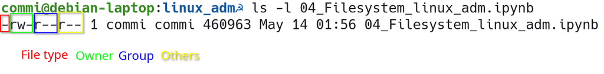

```bash
ls -l 04_Filesystem_linux_adm.ipynb
```

```
-rw-r--r-- 1 commi commi 460237 May 14 01:54 04_Filesystem_linux_adm.ipynb
```

### `ugo`

Nine permission bits determine what operations can be performed on a file and by whom. Traditional UNIX does not allow permissions to be set per user (although all systems now support access control lists of one sort or another).

Instead, three sets of permissions define access for

- the owner (`u`ser) of the file,
- the `g`roup owners of the file, and
- everyone else (`o`ther)

(in that order).

If you think of the owner as “the user” and everyone else as “other,” you can remember the order of the permission sets by thinking of the name H**ugo**. **u**, **g**, and **o** are also the letter codes used by the mnemonic version of `chmod`.

Each set has three bits:

| mnemonic syntax | octal number |
| --- | --- |
| `r`ead bit | 4 |
| `w`rite bit | 2 |
| e`x`ecute bit | 1 |
| `a`ll |  |

(in that order)

So, `777` is the same as `rwxrwxrwx`.

It’s convenient to discuss file permissions in terms of octal (base 8) numbers because each digit of an octal number represents three bits and each group of permission bits consists of three bits.

The topmost three bits with octal values of

- 400,
- 200, and
- 100

control access for the owner.

The second three

- 40,
- 20, and
- 10

control access for the group.

The last three

- 4,
- 2, and
- 1

control access for everyone else (“the world”).

In each triplet, the high bit is the `r`ead bit, the middle bit is the `w`rite bit, and the low bit is the e`x`ecute bit.

Although a user might fit into two of the three permission categories, only the most specific permissions apply. For example, the owner of a file always has access determined by the owner permission bits and never by the group permission bits. It is possible for the “other” and “group” categories to have more access than the owner, although this configuration would be highly unusual.

*ChatGPT*:

1. **Specificity of Permissions:**
- The system first checks if the user is the owner.
- If not, it checks if the user is part of the group.
- If neither, it applies the "others" permissions.
2. **Example Analysis:**
- If a user is both the owner of a file and part of its group, the system will apply the owner permissions.
- If the owner has specific permissions, these override any group permissions that might apply to them.

### On a regular file

On a regular file

- the read bit allows the file to be opened and read,
- the write bit allows the contents of the file to be modified or truncated;

however,

> the ability to delete or rename (or delete and then re-create!) the file is controlled by the permissions on its parent directory, where the name-to-dataspace mapping is actually stored.

The execute bit allows the file to be executed. Two types of executable files exist:

- **binaries**, which the CPU runs directly, and
- **scripts**, which must be interpreted by a shell or some other program.

By convention, scripts begin with a line similar to `#!/usr/bin/perl` that specifies an appropriate interpreter. Nonbinary executable files that do not specify an interpreter are assumed to be `sh` scripts.

> The kernel understands the `#!` (“shebang”) syntax and acts on it directly. However, if the interpreter is not specified completely and correctly, the kernel will refuse to execute the file. The shell then makes a second attempt to execute the script by calling `/bin/sh`, which is usually a link to the [Almquist shell](https://en.wikipedia.org/wiki/Almquist_shell) or to bash (also see dash). Sven Mascheck maintains an excruciatingly detailed page about the history, implementation, and cross-platform behavior of the shebang in his ["The #! magic, details about the shebang/hash-bang mechanism on various Unix flavours"](https://www.in-ulm.de/~mascheck/various/shebang/).

### On a directory

For a directory, the *execute bit* (often called the “search” or “scan” bit in this context) allows the directory to be entered or passed through as a pathname is evaluated, but not to have its contents listed.

- The combination of *`r`ead and e`x`ecute* bits allows the contents of the directory to be listed.
- The combination of *`w`rite and e`x`ecute* bits allows files to be created, deleted, and renamed within the directory.

```bash
ls -ld
```

```
drwxr-xr-x 5 commi commi 4096 May 14 02:50 ./
```

So, the files in the current directory can be listed by groups and others, but not modified.

> **NOTE**: A variety of extensions such as **access control lists**, SELinux, and “bonus” permission bits defined by individual filesystems complicate or override the traditional 9-bit permission model. If you’re having trouble explaining the system’s observed behavior, check to see whether one of these factors might be interfering.

```bash
ls -ld /tmp
```

```
drwxrwxrwt 23 root root 40960 May 19 01:18 /tmp/
```

### On a script

For a shell script, it would need both permission turned on. For the script to be run by an interpreter, it must be opened and read like a text file. Binary files are executed directly by the kernel and therefore do not need read permission turned on.

- `r`ead and e`x`ecute

## The `s`et`u`id and `s`et`g`id bits

- `4000` or `u+s` - **setuid** bit,
- `2000` or `g+s` - **setgid** bit.

When set on executable files, these bits allow programs to access files and processes that would otherwise be off-limits to the user that runs them. See also "Access and Rootly Power".

When set on a directory, the setgid bit causes newly created files within the directory to take on the group ownership of the directory rather than the default group of the user that created the file. This convention makes it easier to share a directory of files among several users, as long as they belong to a common group. This interpretation of the setgid bit is unrelated to its meaning when set on an executable file, but no ambiguity can exist as to which meaning is appropriate.

*ChatGPT:*  
Both shared groups and the setgid (Set Group ID) permission serve as mechanisms to facilitate shared access to directories among group members. Let's compare them:

**Shared Group**:

- Involves creating a dedicated group specifically for users who require access to the shared directory.
- Users who need access are added to this group using tools like `usermod` or by editing the `/etc/group` file.
- Group ownership and permissions are manually set on the shared directory to grant access to the group.
- Provides a straightforward approach to managing access control by organizing users into a single group with shared permissions.
- Does not automatically inherit group ownership for newly created files and directories within the shared directory.
- Relies on manual administration to ensure that users are added to the appropriate group and that group permissions are set correctly.

**Setgid**:

- Involves setting the setgid bit on the parent directory using the `chmod g+s` command.
- Ensures that newly created files and directories within the parent directory inherit the group ownership of the parent directory.
- Simplifies access control by automatically inheriting group ownership for newly created files and directories, eliminating the need for manual intervention.
- Provides a more automated approach to managing shared access, as any user who has write access to the parent directory can create files and directories that are automatically shared among group members.
- Can be combined with shared groups to further refine access control, ensuring that only members of the appropriate group have access to the shared directory.

In summary, shared groups provide a straightforward way to organize users into groups with shared permissions, while setgid simplifies access control by automatically inheriting group ownership for newly created files and directories. Depending on your requirements and preferences, you may choose to use one or both of these mechanisms to facilitate shared access to directories among group members.

### From "Access control"

`Setuid` and `setgid` execution.

Traditional UNIX access control is complemented by an identity substitution system that’s implemented by the kernel and the filesystem in collaboration. This scheme allows specially marked executable files to run with elevated permissions, usually those of root. It lets developers and administrators set up structured ways for unprivileged users to perform privileged operations.

When the kernel runs an executable file that has its “setuid” or “setgid” permission bits set, it changes the effective UID or GID of the resulting process to the UID or GID of the file containing the program image rather than the UID and GID of the user that ran the command. The user’s privileges are thus promoted for the execution of that specific command only.

*ChatGPT*:  
In this context, "effective" refers to the user or group identity that the operating system considers when determining access rights and permissions for a process. Here's a breakdown:

- **Real UID/GID**: This is the actual user or group identity of the user who executed the program.
- **Effective UID/GID**: This is the user or group identity that the operating system uses to determine permissions for the process while it is running.

"*When an executable file has its "setuid" or "setgid" permission bits set, the effective UID or GID of the resulting process is changed to match the UID or GID of the file containing the program image*". This means that the process temporarily adopts the permissions of the owner or group associated with the executable file, allowing it to access resources or perform actions that would typically be restricted to that owner or group.

Understanding the distinction between real and effective UID/GID is crucial for ensuring proper security and access control in a multi-user environment.

The term **"effective"** in the context of computing, particularly in operating systems, likely originates from its usage in broader contexts where it denotes the actual, functional, or operative state of something. Here are some possible roots and influences on the term:

1. **Etymology:**
- The term "effective" traces its roots to the Latin word "effectivus," which means "productive" or "efficient." In English, "effective" is used to describe something that has the power to produce a desired result or influence.
2. **Computing Usage:**
- In the context of computing, "effective" is often used to describe the state or condition of something that is actively functioning or operational. For example, "effective permissions" refer to the actual permissions that are applied and enforced, as opposed to potential or nominal permissions.
3. **Operating Systems:**
- In operating systems, particularly Unix-like systems, the concept of "effective UID/GID" emerged as a way to manage and enforce access control. The "effective" UID/GID represents the user or group identity that is actively used for permission checks and resource access during the execution of a process.
4. **Security and Access Control:**
- The concept of "effective UID/GID" is closely tied to security and access control mechanisms in operating systems. By temporarily changing the effective UID/GID of a process based on certain conditions (e.g., setuid/setgid permissions), the operating system can enforce restrictions and ensure that processes operate within the confines of predefined permissions.

Overall, the term "effective" in computing likely draws from its broader usage in language and has been adapted to describe the functional state or condition of various components, particularly in the realm of operating systems and access control mechanisms.

For example, users must be able to change their passwords. But since passwords are (traditionally) stored in the protected `/etc/master.passwd` or `/etc/shadow` file, users need a `setuid passwd` command to mediate their access. The `passwd` command checks to see who’s running it and customizes its behavior accordingly: users can change only their own passwords, but root can change any password.

```bash
ls -l /etc/shadow
```

```
-rw-r----- 1 root shadow 1128 Mar 15 02:33 /etc/shadow
```

```bash
ls -l /usr/bin/passwd
```

```
-rwsr-xr-x 1 root root 68248 Mar 23  2023 /usr/bin/passwd*
```

Programs that run setuid, especially ones that run setuid to root, are prone to security problems. The setuid commands distributed with the system are theoretically secure; however, security holes have been discovered in the past and will undoubtedly be discovered in the future.

The surest way to minimize the number of setuid problems is to

> minimize the number of setuid programs.

Think twice before installing software that needs to run setuid, and

> avoid using the setuid facility in your own home-grown software.

Never use setuid execution on programs that were not explicitly written with setuid execution in mind.

You can disable setuid and setgid execution on individual filesystems by specifying the `nosuid` option to mount. It’s a good idea to use this option on filesystems that contain users’ `home` directories or that are mounted from less trustworthy administrative domains.

### Examples

Example of `setuid` bit on a file:

```bash
cd /tmp
touch test_setuid

chmod 4664 test_setuid
ls -l test_setuid

rm -rf test_setuid
```

```
-rwSrw-r-- 1 commi commi 0 May 19 01:35 test_setuid
```

```bash
cd /tmp
touch test_setuid

chmod u+s test_setuid
ls -l test_setuid

rm -rf test_setuid
```

```
-rwSr--r-- 1 commi commi 0 May 19 01:40 test_setuid
```

```bash
cd /tmp
touch test_setuid

chmod 2664 test_setuid
ls -l test_setuid

rm -rf test_setuid
```

```
-rw-rwSr-- 1 commi commi 0 May 19 01:41 test_setuid
```

Example of `setgid` bit on a file:

```bash
cd /tmp
touch test_setgid

chmod g+s test_setgid
ls -l test_setgid

rm -rf test_setgid
```

```
-rw-r-Sr-- 1 commi commi 0 May 19 01:43 test_setgid
```

Example of both `setuid` and `setgid` on a file:

```bash
cd /tmp
touch test_set_uid_gid

chmod +s test_set_uid_gid
ls -l test_set_uid_gid

rm -rf test_set_uid_gid
```

```
-rwSr-Sr-- 1 commi commi 0 May 19 01:43 test_set_uid_gid
```

Example of `setuid` on a directory:

```bash
cd /tmp
mkdir test_setuid

chmod 4664 test_setuid
ls -ld test_setuid

rm -rf test_setuid
```

```
drwSrw-r-- 2 commi commi 4096 May 19 01:44 test_setuid/
```

```bash
cd /tmp
mkdir test_setuid

chmod u+s test_setuid
ls -ld test_setuid

rm -rf test_setuid
```

```
drwsr-xr-x 2 commi commi 4096 May 19 01:44 test_setuid/
```

Example of `setgid` on a directory:

```bash
cd /tmp
mkdir test_setgid

chmod 2664 test_setgid
ls -ld test_setgid

rm -rf test_setgid
```

```
drw-rwSr-- 2 commi commi 4096 May 19 01:45 test_setgid/
```

```bash
cd /tmp
mkdir test_setgid

chmod g+s test_setgid
ls -ld test_setgid

rm -rf test_setgid
```

```
drwxr-sr-x 2 commi commi 4096 May 19 01:45 test_setgid/
```

Example of both `setuid` and `setgid` on a directory:

```bash
cd /tmp
mkdir test_set_uid_gid

chmod +s test_set_uid_gid
ls -ld test_set_uid_gid

rm -rf test_set_uid_gid
```

```
drwsr-sr-x 2 commi commi 4096 May 19 01:48 test_set_uid_gid/
```

### Disable `suid`

If either the setuid/setgid bit or the sticky bit is set but the corresponding execute bit is not, these bits are shown as `S` or `T`.

*ChatGPT*:

- **Lowercase 's':**
  - Represents the setgid bit being set and the `execute` (search) permission being set for that category (owner, group, or others).
  - Example: `drwxr-sr-x` (the `s` in the group section means setgid is set, and execute permission is also set for the group).
- **Uppercase 'S':**
  - Represents the setgid bit being set but the `execute` (search) permission not being set for that category.
  - Example: `drw-rwSr--` (the `S` in the group section means setgid is set, but execute permission is not set for the group).

```
vi /etc/fstab

# add nosuid option
/dev/sdb1  /mnt/myfilesystem  ext4  defaults,nosuid  0  2
:wq

mount -o remount /mnt/myfilesystem
mount | grep /mnt/myfilesystem
```

```bash
mount | grep /home
```

```
/dev/sda4 on /home type ext4 (rw,relatime)
```

## The s`t`icky bit

- `1000` or `+t`

The bit with octal value `1000` is called the **sticky bit**. It was of historical importance as a modifier for executable files on early UNIX systems. However, that meaning of the sticky bit is now obsolete and modern systems silently ignore the sticky bit when it’s set on regular files.

If the sticky bit is set on a directory, the filesystem won’t allow you to delete or rename a file unless you are the owner of the directory, the owner of the file, or the superuser. Having write permission on the directory is not enough. This convention helps make directories like `/tmp` a little more private and secure.

```bash
our_dir=test_dir

cd /tmp
mkdir $our_dir

chmod +t $our_dir
ls -ld $our_dir

rm -rf $our_dir
```

```
drwxr-xr-t 2 commi commi 4096 May 19 02:10 test_dir/
```

```bash
our_dir=test_dir

cd /tmp
mkdir $our_dir

chmod 1777 $our_dir
ls -ld $our_dir

rm -rf $our_dir
```

```
drwxrwxrwt 2 commi commi 4096 May 19 02:10 test_dir/
```

```bash
our_dir=test_dir

cd /tmp
mkdir $our_dir

chmod 2777 $our_dir
chmod +t $our_dir

ls -ld $our_dir

rm -rf $our_dir
```

```
drwxrwsrwt 2 commi commi 4096 May 19 02:11 test_dir/
```

```bash
our_dir=test_dir

cd /tmp
mkdir $our_dir

chmod 2766 $our_dir
chmod +t $our_dir

ls -ld $our_dir

rm -rf $our_dir
```

```
drwxrwSrwT 2 commi commi 4096 May 19 02:13 test_dir/
```

If either the setuid/setgid bit or the sticky bit is set but the corresponding execute bit is not, these bits are shown as `S` or `T`.

*ChatGPT*:

- **Lowercase 's':**
  - Represents the setgid bit being set and the `execute` (search) permission being set for that category (owner, group, or others).
  - Example: `drwxr-sr-x` (the `s` in the group section means setgid is set, and execute permission is also set for the group).
- **Uppercase 'S':**
  - Represents the setgid bit being set but the `execute` (search) permission not being set for that category.
  - Example: `drw-rwSr--` (the `S` in the group section means setgid is set, but execute permission is not set for the group).

## `chmod`

- change the permissions on a file,
- only the owner of the file and the superuser can change a file’s permissions.

You can use either mnemonic or octal syntax:

Examples of chmod’s mnemonic syntax

| Spec | Meaning |
| --- | --- |
| `u+w` | Adds write permission for the owner of the file |
| `ug=rw,o=r` | Gives r/w permission to owner and group, and read permission to others |
| `a-x` | Removes execute permission for all categories (owner/group/other) |
| `ug=srx,o=` | Makes setuid/setgid and gives r/x permission to only owner and group |
| `g=u` | Makes the group permissions be the same as the owner permissions |

Octal syntax:

```bash
cd /tmp

fname='test.txt'
touch $fname
ls -l $fname

echo "Let's change permissions:"
chmod 660 $fname
ls -l $fname

echo "Let's add setuid bit"
chmod 4660 $fname
ls -l $fname

rm -f $fname
```

```
-rw-r--r-- 1 commi commi 0 May 26 01:47 test.txt
Let's change permissions:
-rw-rw---- 1 commi commi 0 May 26 01:47 test.txt
Let's add setuid bit
-rwSrw---- 1 commi commi 0 May 26 01:47 test.txt
```

### `--reference`

On Linux systems, you can also specify the modes to be assigned by copying them from an existing file. For example, `chmod --reference=filea fileb` makes `fileb`’s mode the same as `filea`’s.

```bash
cd /tmp

fname='test.txt'
fname2='test2.txt'
touch $fname
touch $fname2

ls -l $fname
ls -l $fname2

echo "Let's change permissions to $fname:"
chmod 660 $fname
ls -l $fname
ls -l $fname2

echo "And apply the same permissions on $fname2 by copying them from $fname:"
chmod --reference=$fname $fname2
ls -l $fname
ls -l $fname2

rm -f $fname
rm -f $fname2
```

```
-rw-r--r-- 1 commi commi 0 May 26 01:58 test.txt
-rw-r--r-- 1 commi commi 0 May 26 01:58 test2.txt
Let's change permissions to test.txt:
-rw-rw---- 1 commi commi 0 May 26 01:58 test.txt
-rw-r--r-- 1 commi commi 0 May 26 01:58 test2.txt
And apply the same permissions on test2.txt by copying them from test.txt:
-rw-rw---- 1 commi commi 0 May 26 01:58 test.txt
-rw-rw---- 1 commi commi 0 May 26 01:58 test2.txt
```

### `-R` | recursive

With the `-R` option, `chmod` recursively updates the file permissions within a directory. However, this feature is trickier than it looks because the enclosed files and directories may not share the same attributes; for example, some might be executable files; others, text files. Mnemonic syntax is particularly useful with `‐R` because it preserves bits whose values you don’t set explicitly. For example,

```
$ chmod -R g+w mydir
```

adds group write permission to `mydir` and all its contents without messing up the execute bits of directories and programs.

If you want to adjust execute bits, be wary of `chmod -R`. It’s blind to the fact that the execute bit has a different interpretation on a directory than it does on a flat file. Therefore, `chmod -R a-x` probably won’t do what you intend. Use find to select only the regular files:

```
$ find mydir -type f -exec chmod a-x {} ';'
```

## `umask`

- assign default permissions

You can use the built-in shell command `umask` to influence the default permissions given to the files you create. Every process has its own `umask` attribute; the shell’s built-in `umask` command sets the shell’s own `umask`, which is then inherited by commands that you run.

The `umask` is specified as a three-digit octal value that represents the permissions *to take away*. When a file is created, its permissions are set to whatever the creating program requests minus whatever the `umask` forbids. Thus, the individual digits of the `umask` allow the permissions shown in Table 5.5.

Permission encoding for `umask`

| Octal | Binary | Perms | Octal | Binary | Perms |
| --- | --- | --- | --- | --- | --- |
| 0 | 000 | --- | 4 | 100 | r-- |
| 1 | 001 | --x | 5 | 101 | r-x |
| 2 | 010 | -w- | 6 | 110 | rw- |
| 3 | 011 | -wx | 7 | 111 | rwx |

```bash
type umask
```

```
umask is a shell builtin
```

The default `umask` value is often `022`, which denies write permission to the group and world but allows read permission.

```bash
umask
```

```
0022
```

## Linux bonus flags

Linux defines a set of supplemental flags that can be set on files to request special handling. For example, the `a` flag makes a file append-only, and the `i` flag makes it immutable and undeletable.

Flags have binary values, so they are either present or absent for a given file. The underlying filesystem implementation must support the corresponding feature, so not all flags can be used on all filesystem types. In addition, some flags are experimental, unimplemented, or read-only.

Linux uses the commands `lsattr` and `chattr` to view and change file attributes.

The main thing to remember is that

> if a particular file seems to be behaving strangely, check it with `lsattr` to see if it has one or more flags enabled.

```bash
lsattr ./04_Filesystem_linux_adm.ipynb
```

```
--------------e------- ./04_Filesystem_linux_adm.ipynb
```

```bash
lsattr -l ./04_Filesystem_linux_adm.ipynb
```

```
./04_Filesystem_linux_adm.ipynb Extents
```

### `A` flag

Waiving maintenance of last-access times (the `A` flag) can boost performance in some situations. However, its value depends on the filesystem implementation and access pattern; you’ll have to do your own benchmarking. In addition, modern kernels now default to mounting filesystems with the relatime option, which minimizes updates to `st_atime` and makes the `A` flag largely obsolete.

*ChatGPT*:  
`st_atime` is a field in the `stat` structure in Unix-like operating systems. It stands for "last access time" and records the last time a file was accessed (read).

When a file is accessed, the `st_atime` attribute is updated to reflect this access. This can include activities such as reading the file content or executing a file.

**`relatime` Option:**

Modern kernels often mount filesystems with the `relatime` (relative access time) option by default. This option reduces the frequency of updates to the `st_atime` attribute, thereby improving performance by minimizing unnecessary disk writes. Specifically, `relatime` updates `st_atime` only under the following conditions:

- If the previous access time is older than the modification time (`st_mtime`) or status change time (`st_ctime`).
- If the previous access time is more than 24 hours old.

**`A` Flag:**

The `A` flag, when set, prevents the system from updating the `st_atime` attribute at all. This can further enhance performance, especially for applications that frequently read files but do not need to track access times.

**Impact of `relatime` on the `A` Flag:**

With the `relatime` option being the default in modern kernels, the frequent updates to `st_atime` are already minimized, making the explicit use of the `A` flag largely obsolete. This is because `relatime` strikes a balance between performance and the need to have relatively accurate access time records without the overhead of updating `st_atime` on every file access.

**Summary:**

- **`st_atime`**: Records the last access time of a file.
- **`relatime`**: A mount option that reduces the frequency of `st_atime` updates.
- **`A` Flag**: Prevents `st_atime` updates entirely.

In modern systems, due to the `relatime` mount option, the need to use the `A` flag for performance reasons is reduced.

### `i` and `a` flag

The immutable and append-only flags (`i` and `a`) were largely conceived as ways to make the system more resistant to tampering by hackers or hostile code. Unfortunately, they can confuse software and protect only against hackers that don’t know enough to use `chattr -ia`. Real-world experience has shown that these flags are more often used *by* hackers than against them.

We have seen several cases in which admins have used the `i` (immutable) flag to prevent changes that would otherwise be imposed by a configuration management system such as Ansible or Salt. Needless to say, this hack creates confusion once the details have been forgotten and no one can figure out why configuration management isn’t working. **Never do this**.

### `d` flag

The “no backup” flag (`d`) is potentially of interest to administrators, but since it’s an advisory flag, make sure that your backup system honors it.

`D`, `j`, and `S`

Flags that affect journaling and write synchrony (`D`, `j`, and `S`) exist primarily to support databases. They are not of general use for administrators. All these options can reduce filesystem performance significantly. In addition, tampering with write synchrony has been known to confuse `fsck` on `ext*` filesystems.

## ACLs - Access Control Lists

Access control lists, aka ACLs, are a more powerful but also more complicated way of regulating access to files. Each file or directory can have an associated ACL that lists the permission rules to be applied to it. Each of the rules within an ACL is called an access control entry or ACE.

ACLs have a niche, but it lies outside the mainstream of UNIX and Linux administration. ACLs exist primarily to facilitate Windows compatibility and to serve the needs of the small segment of enterprises that actually require ACL-level flexibility. They are not the shiny next generation of access control and are not intended to supplant the traditional model.

*So read the book "Unix and Linux System Administration Handbook" by Evi Nemeth, Garth Snyder, Trent R. Hein, Ben Whaley, and Dan Mackin, if you need ACLs* - VR.

```bash
ls -l 04_Filesystem_linux_adm.ipynb
```

```
-rw-r--r-- 1 commi commi 154281 May 27 19:36 04_Filesystem_linux_adm.ipynb
```

```bash
getfacl ./04_Filesystem_linux_adm.ipynb
```

```
# file: 04_Filesystem_linux_adm.ipynb
# owner: commi
# group: commi
user::rw-
group::r--
other::r--
```

```bash
getfacl --omit-header ./04_Filesystem_linux_adm.ipynb
```

```
user::rw-
group::r--
other::r--
```